# Predicting with trees, Random Forests, & Model Based Predictions

Practical Machine Learning: Week 3 Coursera Data Science: Statistics & Machine Learning Specialization

Mircea Dumitru

17 August, 2023

# Predicting with trees

## Key ideas

- Iteratively split variables into groups.
- Evaluate *homogeneity* within each group.
- Split again if necessary.

**Pros**

- Easy to interpret.
- Better performances in non-linear settings.

**Cons**

- Without prunning/cross-validation can lead to overfitting.
- Harder to estimate uncertainty.
- Results may be variable, depending the exact values of the parameters or the collected variables.

## Basic algorithm

1. Start with all variables in one group
2. Find the variable/split that best separates the outcome
3. Divide the data into two groups (*leaves*) on that split (*node*)
4. Within each split, find the best variable/split that separates the outcomes
5. Continue until the groups are too small or sufficiently *pure*

## Measures of impurity

Multiple measures of impurity, most of which are based on the probability

$$\widehat{p}_{mk}
=
\frac{1}{N_m}
\sum_{x_i \in \text{Leaf}_m}
\mathbb{1}\left( y_i = k \right)$$
where $m$ represents the group (the leaf), $N_m$ the number of variables (objects) and $k$ represents a class.

**Misclassification Error**:

$$1 - \widehat{p}_{mk(m)},
\quad
k(m) - \text{most common k}$$

- 0 - perfect purity
- 0.5 - no purity

**Gini Index**:

For a set of items with $J$ classes and relative frequencies $p_i$, $i \in \{ 1, 2, \ldots, J \}$, the probability of choosing an item with label $i$ is $p_{i}$, and the probability of miscategorizing that item is $\sum_{k \neq i} p_{k} = 1 - p_{i}$. The Gini impurity is computed by summing pairwise products of these probabilities for each class label:

$$I_{G}(p)
=
\sum_{i}^{J}
p_{i}
\left(
\sum_{k \neq i}
p_{k}
\right)
=
\sum_{i}^{J}
p_{i}
\left(
1 - p_{i}
\right)
=
1
-
\sum_{k=1}^{J}
p_i^2$$

- 0 - perfect purity
- 0.5 - no purity

**Deviance/information gain**:

The information gain $\operatorname{I}_{E} \left( p_{1}, p_{2}, \ldots, p_{J} \right)$ is based on the entropy:
$$\operatorname{I}_{E}
\left(
p_{1},
\ldots,
p_{J}
\right)
=
-\sum_{i=1}^{J}
p_{i} \log_{2} p_{i}$$
where $p_{1}, \ldots, p_{J}$ are fractions that add up to 1 and represent the percentage of each class present in the child node that results from a split in the tree.

- 0 - perfect purity
- 1 - no purity

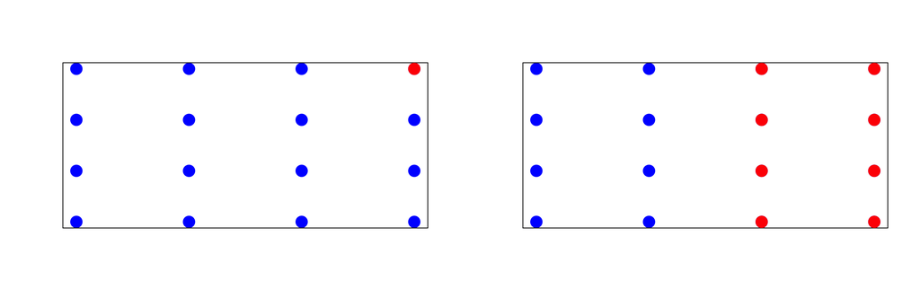

```r
par(mfrow = c(1,2))
x <- rep(c(1,2,3,4), each = 4)
y <- rep(c(1,2,3,4), 4)
plot(x, y,
     pch = 19, cex = 2, col = 'blue',
     xlab='', ylab = '',
     xaxt = "n", yaxt = "n")
points(x[length(x)], y[length(y)], pch = 19, cex = 2, col = 'red')

plot(x, y,
     pch = 19, cex = 2, col = 'blue',
     xlab='', ylab = '',
     xaxt = "n", yaxt = "n")
points(x[length(x)/2+1:length(x)], y[length(y)/2+1:length(y)], pch = 19, cex = 2, col = 'red')
```

$$\begin{equation*}
\begin{aligned}[c]
\text{Misclassification: }
1 - 15/16 = 1/16 \approx 0.06
\\
\text{Gini: }
1 - \left[ \left(\frac{1}{16}\right)^2 + \left(\frac{15}{16}\right)^2
\right] = 1 - \frac{226}{256} = \frac{30}{256} \approx 0.12
\\
\text{Information: }
-\left[ \frac{1}{16} \log_2\left( \frac{1}{16} \right) +
\frac{15}{16}\log_2\left(\frac{15}{16}\right) \right] \approx 0.34
\end{aligned}
\qquad\qquad
\begin{aligned}[c]
\text{Misclassification: }
1 - 8/16 = 8/16 = 0.5
\\
\text{Gini: }
1 - \left[ \left(\frac{1}{2}\right)^2 + \left(\frac{1}{2}\right)^2
\right] = 1 - \frac{1}{2} = 0.5
\\
\text{Information: }
-\left[ 2 \frac{1}{2} \log_2\left( \frac{1}{2} \right) \right] = 1
\end{aligned}
\end{equation*}$$

## Example Iris Data

```r
data(iris)
library(ggplot2)
names(iris)
```

```
## [1] "Sepal.Length" "Sepal.Width"  "Petal.Length" "Petal.Width"  "Species"
```

```r
table(iris$Species)
```

```
##
##     setosa versicolor  virginica
##         50         50         50
```

```r
library(caret)
inTrain <- createDataPartition(y = iris$Species,
                               p = 0.7,
                               list = FALSE)
training <- iris[inTrain,]
testing <- iris[-inTrain,]
dim(training)
```

```
## [1] 105   5
```

```r
dim(testing)
```

```
## [1] 45  5
```

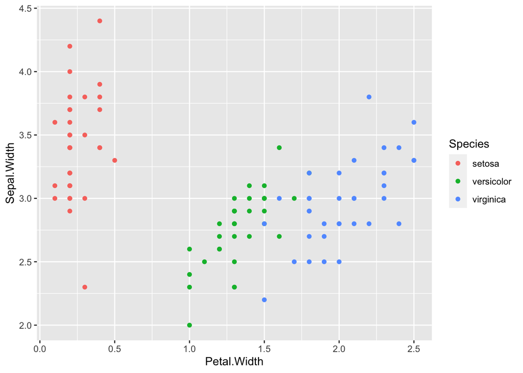

```r
library(ggplot2)
g <- ggplot(data = training,
      aes(x = Petal.Width, y = Sepal.Width,
          colour = Species))
g <- g + geom_point()
g
```

```r
modFit <- train(Species ~ .,
                method = 'rpart',
                data  = training)
print(modFit$finalModel)
```

```
## n= 105
##
## node), split, n, loss, yval, (yprob)
##       * denotes terminal node
##
## 1) root 105 70 setosa (0.33333333 0.33333333 0.33333333)
##   2) Petal.Length< 2.45 35  0 setosa (1.00000000 0.00000000 0.00000000) *
##   3) Petal.Length>=2.45 70 35 versicolor (0.00000000 0.50000000 0.50000000)
##     6) Petal.Length< 4.75 33  1 versicolor (0.00000000 0.96969697 0.03030303) *
##     7) Petal.Length>=4.75 37  3 virginica (0.00000000 0.08108108 0.91891892) *
```

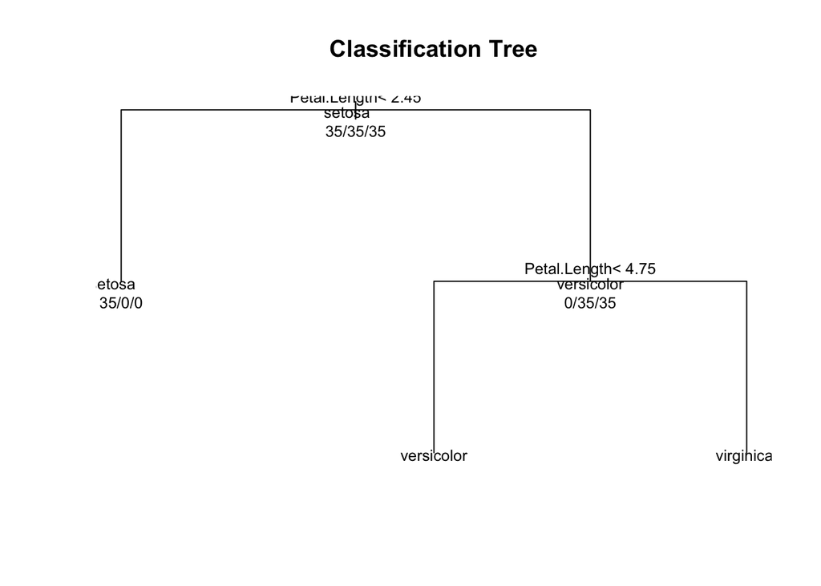

```r
plot(modFit$finalModel, uniform = TRUE,
     main = 'Classification Tree')
text(modFit$finalModel,
     use.n = T,
     all = T,
     cex = .8)
```

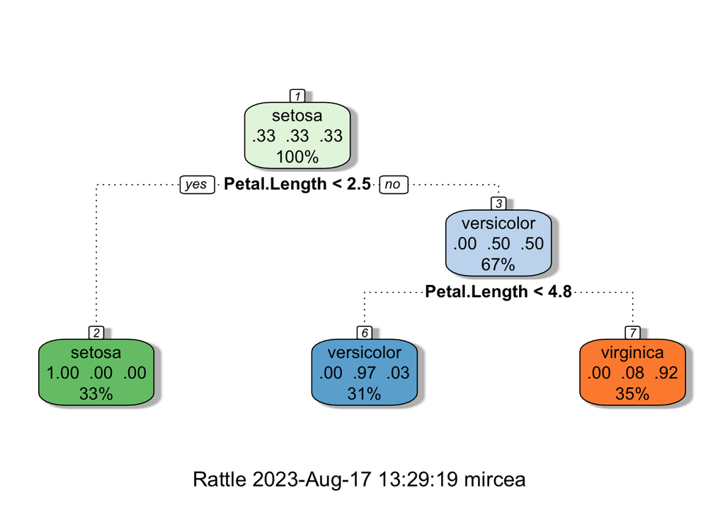

```r
library(rattle)
fancyRpartPlot(modFit$finalModel)
```

```r
predict(modFit, newdata = testing)
```

```
##  [1] setosa     setosa     setosa     setosa     setosa     setosa
##  [7] setosa     setosa     setosa     setosa     setosa     setosa
## [13] setosa     setosa     setosa     versicolor versicolor virginica
## [19] versicolor versicolor versicolor versicolor versicolor versicolor
## [25] virginica  virginica  versicolor versicolor versicolor versicolor
## [31] virginica  virginica  virginica  virginica  virginica  virginica
## [37] virginica  virginica  virginica  virginica  virginica  virginica
## [43] virginica  virginica  virginica
## Levels: setosa versicolor virginica
```

```r
confusionMatrix(factor(testing$Species),
                factor(predict(modFit, newdata = testing)))
```

```
## Confusion Matrix and Statistics
##
##             Reference
## Prediction   setosa versicolor virginica
##   setosa         15          0         0
##   versicolor      0         12         3
##   virginica       0          0        15
##
## Overall Statistics
##
##                Accuracy : 0.9333
##                  95% CI : (0.8173, 0.986)
##     No Information Rate : 0.4
##     P-Value [Acc > NIR] : 6.213e-14
##
##                   Kappa : 0.9
##
##  Mcnemar's Test P-Value : NA
##
## Statistics by Class:
##
##                      Class: setosa Class: versicolor Class: virginica
## Sensitivity                 1.0000            1.0000           0.8333
## Specificity                 1.0000            0.9091           1.0000
## Pos Pred Value              1.0000            0.8000           1.0000
## Neg Pred Value              1.0000            1.0000           0.9000
## Prevalence                  0.3333            0.2667           0.4000
## Detection Rate              0.3333            0.2667           0.3333
## Detection Prevalence        0.3333            0.3333           0.3333
## Balanced Accuracy           1.0000            0.9545           0.9167
```

## Notes

- Classifcation trees are non-linear models
  - They use interactions between variables
  - Data transformations may be less important (monotone transformations)
  - Trees can alos be used for regression problems (continous outcome)
- Note that there are multiple tree building options in `R` both
  - in the `caret` package
    - party, rpart
  - out of the `caret` package
    - tree

# Bootstrap aggregating (Bagging)

Basic idea: 1. Resample cases and recalculate predictions 2. Average or majority vote

Notes: * Similar bias (as fitting any of the individual models) * Reduced variance * More useful for non-linear functions

## Ozone data

```r
library(ElemStatLearn)
data(ozone, package = 'ElemStatLearn')

ozone <- ozone[order(ozone$ozone),]
head(ozone)
```

```
##     ozone radiation temperature wind
## 17      1         8          59  9.7
## 19      4        25          61  9.7
## 14      6        78          57 18.4
## 45      7        48          80 14.3
## 106     7        49          69 10.3
## 7       8        19          61 20.1
```

### Bagged loess

```r
ll <- matrix(NA, nrow = 10, ncol = 155)
for(i in 1 : 10){
    ss <- sample(1:dim(ozone)[1], replace = T)
    ozone0 <- ozone[ss,]
    ozone0 <- ozone0[order(ozone0$ozone),]
    loess0 <- loess(temperature ~ ozone,
                    data = ozone0, span = 0.2)
    ll[i,] <- predict(loess0,
                      newdata = data.frame(ozone=1:155))
}
```

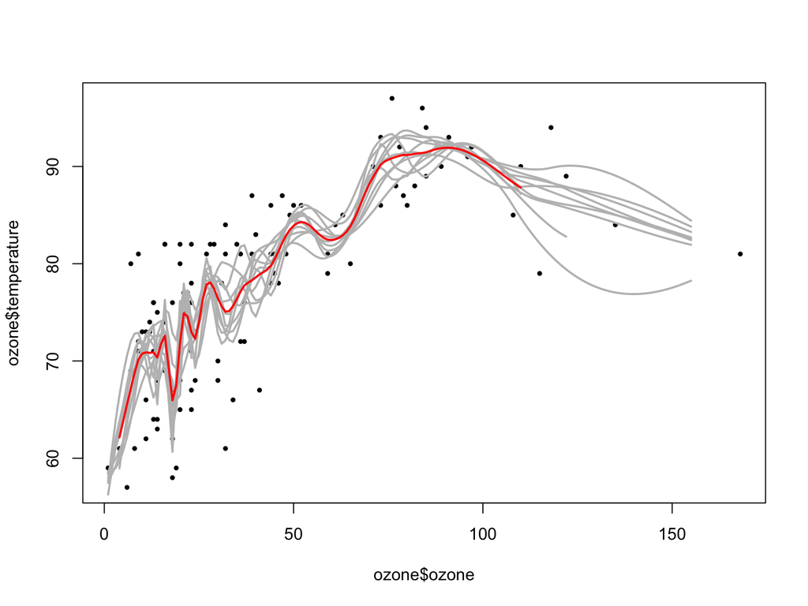

```r
plot(ozone$ozone, ozone$temperature, pch = 19, cex = 0.5)
for(i in 1:10){
    lines(1:155, ll[i,],
          col = 'grey', lwd = 2)
}
lines(1:155, apply(ll, 2, mean), col = 'red', lwd = 2)
```

### Bagging in caret

- Some models perform bagging for you, in `train` function consider method options
  - `bagEarth`
  - `treebag`
  - `bagFDA`
- Alternatively, you can bag any model you choose using the `bag` function.

```r
predictors = data.frame(ozone=ozone$ozone)
temperature = ozone$temperature
treebag <- bag(predictors, temperature, B = 10,
               bagControl = bagControl(fit = ctreeBag$fit,
                                       predict = ctreeBag$pred,
                                       aggregate = ctreeBag$aggregate))
```

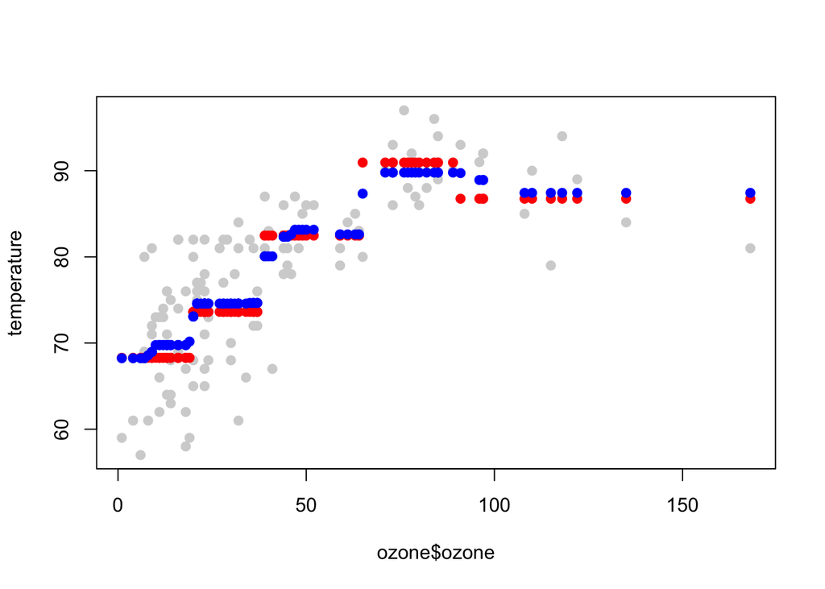

```r
plot(ozone$ozone,
     temperature,
     col = 'lightgrey', pch = 19)
points(ozone$ozone,
       predict(treebag$fits[[1]]$fit,predictors),
       pch = 19, col = 'red')
points(ozone$ozone,
       predict(treebag, predictors),
       pch = 19, col = 'blue')
```

### Parts of bagging

```r
ctreeBag$fit
```

```
## function (x, y, ...)
## {
##     loadNamespace("party")
##     data <- as.data.frame(x, stringsAsFactors = TRUE)
##     data$y <- y
##     party::ctree(y ~ ., data = data)
## }
## <bytecode: 0x1356a0ce8>
## <environment: namespace:caret>
```

```r
ctreeBag$pred
```

```
## function (object, x)
## {
##     if (!is.data.frame(x))
##         x <- as.data.frame(x, stringsAsFactors = TRUE)
##     obsLevels <- levels(object@data@get("response")[, 1])
##     if (!is.null(obsLevels)) {
##         rawProbs <- party::treeresponse(object, x)
##         probMatrix <- matrix(unlist(rawProbs), ncol = length(obsLevels),
##             byrow = TRUE)
##         out <- data.frame(probMatrix)
##         colnames(out) <- obsLevels
##         rownames(out) <- NULL
##     }
##     else out <- unlist(party::treeresponse(object, x))
##     out
## }
## <bytecode: 0x1356a02a0>
## <environment: namespace:caret>
```

```r
ctreeBag$aggregate
```

```
## function (x, type = "class")
## {
##     if (is.matrix(x[[1]]) | is.data.frame(x[[1]])) {
##         pooled <- x[[1]] & NA
##         classes <- colnames(pooled)
##         for (i in 1:ncol(pooled)) {
##             tmp <- lapply(x, function(y, col) y[, col], col = i)
##             tmp <- do.call("rbind", tmp)
##             pooled[, i] <- apply(tmp, 2, median)
##         }
##         if (type == "class") {
##             out <- factor(classes[apply(pooled, 1, which.max)],
##                 levels = classes)
##         }
##         else out <- as.data.frame(pooled, stringsAsFactors = TRUE)
##     }
##     else {
##         x <- matrix(unlist(x), ncol = length(x))
##         out <- apply(x, 1, median)
##     }
##     out
## }
## <bytecode: 0x1356a43f0>
## <environment: namespace:caret>
```

## Notes

- Bagging is most useful for nonlinear models.
- Often used with trees - an extension is random forests.
- Several models use bagging in caret’s `train` function.

# Random Forests

1. Bootstrap samples.
2. At each split, bootstrap variables.
3. Grow multiple trees and vote.

**Pros** 1. Accuracy.

**Cons** 1. Speed. 2. Interpretability. 3. Overfitting.

## Iris data

```r
data(iris)
library(ggplot2)
inTrain <- createDataPartition(y = iris$Species,
                               p = 0.7, list = FALSE)
training <- iris[inTrain,]
testing <- iris[-inTrain,]
```

```r
library(randomForest)
modFit <- train(Species ~ .,
                data = training,
                method = 'rf',
                prox = TRUE)
modFit
```

```
## Random Forest
##
## 105 samples
##   4 predictor
##   3 classes: 'setosa', 'versicolor', 'virginica'
##
## No pre-processing
## Resampling: Bootstrapped (25 reps)
## Summary of sample sizes: 105, 105, 105, 105, 105, 105, ...
## Resampling results across tuning parameters:
##
##   mtry  Accuracy   Kappa
##   2     0.9346186  0.9006027
##   3     0.9344999  0.9004692
##   4     0.9293478  0.8928490
##
## Accuracy was used to select the optimal model using the largest value.
## The final value used for the model was mtry = 2.
```

## Getting a single tree

```r
getTree(modFit$finalModel, k = 2, labelVar=FALSE)
```

```
##    left daughter right daughter split var split point status prediction
## 1              2              3         4        0.70      1          0
## 2              0              0         0        0.00     -1          1
## 3              4              5         4        1.75      1          0
## 4              6              7         3        5.35      1          0
## 5              8              9         2        3.15      1          0
## 6             10             11         4        1.65      1          0
## 7              0              0         0        0.00     -1          3
## 8              0              0         0        0.00     -1          3
## 9             12             13         1        6.10      1          0
## 10            14             15         3        5.00      1          0
## 11            16             17         3        4.75      1          0
## 12             0              0         0        0.00     -1          2
## 13             0              0         0        0.00     -1          3
## 14             0              0         0        0.00     -1          2
## 15            18             19         4        1.55      1          0
## 16             0              0         0        0.00     -1          3
## 17             0              0         0        0.00     -1          2
## 18             0              0         0        0.00     -1          3
## 19             0              0         0        0.00     -1          2
```

## Class “centers”

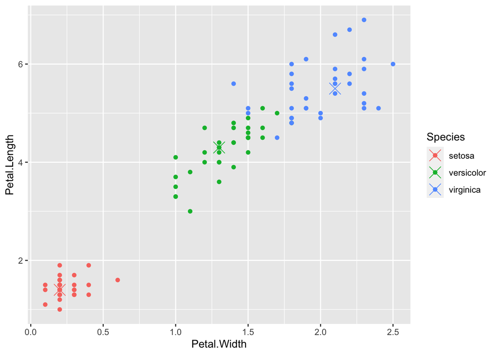

```r
irisP <- classCenter(training[,c(3,4)],
                     training$Species, modFit$finalModel$prox)
irisP <- as.data.frame(irisP)
irisP$Species <- rownames(irisP)
g <- ggplot(data = training,
            aes(x = Petal.Width,
                y = Petal.Length,
                col = Species))
g <- g + geom_point()
g <- g + geom_point(data = irisP,
                    aes(x = Petal.Width,
                        y = Petal.Length,
                        col = Species), size = 5, shape = 4)
g
```

## Predicting new values

```r
pred <- predict(modFit, testing)
table(pred, testing$Species)
```

```
##
## pred         setosa versicolor virginica
##   setosa         15          0         0
##   versicolor      0         15         0
##   virginica       0          0        15
```

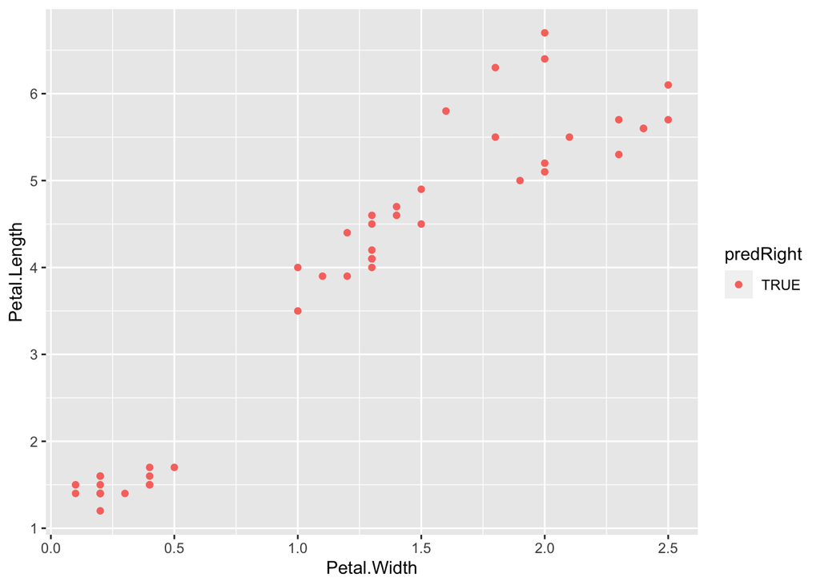

```r
testing$predRight <- pred == testing$Species
g <- ggplot(data = testing,
            aes(x = Petal.Width,
                y = Petal.Length,
                col = predRight),
       main = 'newdata Predictions')
g <- g + geom_point()
g
```

## Notes

- Random Forests are usually one of the two top performing algorithms along with boosting in prediction contests.
- Random Forests are difficult to interpret but often very accurate.
- Care should be taken to avoid overfitting.

# Boosting

1. Take lots of (possible weak) predictors.
2. Weight them and add them up.
3. Get a stronger predictor.

## Basic idea behind boosting

1. Start with a set of classifiers $h_1, \ldots, h_k$.
   - Examples: all possible trees, all possible regression models, all possible cutoffs.
2. Create a classifier that combines classification functions:
   $$\begin{align}
   f(x)
   =
   \mathop{\mathrm{sign}}
   \left(
   \sum_{t = 1}^{T}
   \alpha_t
   h_t(x)
   \right)
   \end{align}$$
- Goal is to minimize error (on the training set).
- Iterative, select one $h$ at each step.
- Calculate weights based on errors.
- Upweight missed classifications and select next $h$.

## Example

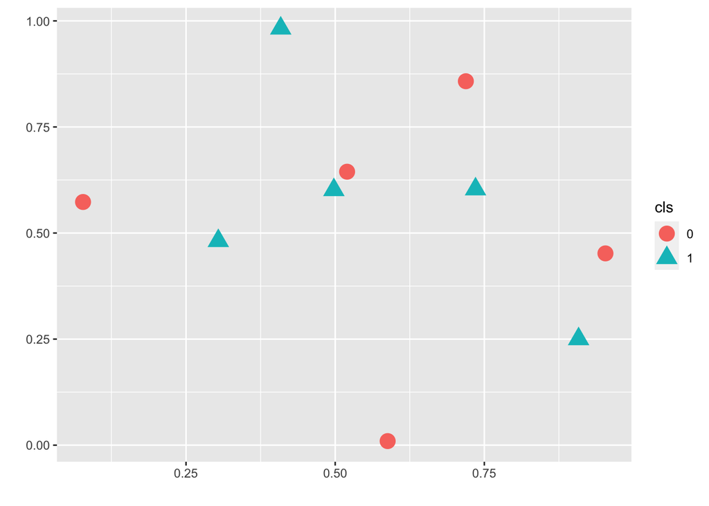

```r
n <- 10
x <- runif(n)
y <- runif(n)
cls <- rep(0, n)
cls[sample(1:n,5,replace = FALSE)] <- 1
cls <- factor(cls)
df <- data.frame(x = x, y = y, cls = cls)
g <- ggplot(data = df, aes(x = x, y = y, col = cls, shape = cls, fill = cls))
g <- g + geom_point(size = 5) + labs(x = '') + labs(y = '')
g
```

The objective is to separate the light blue triangles from the light red circles, with two variables available (one variable corresponding to the $x$ axis, the second one corresponding to the $y$ axis).

## Boosting in R

- Boosting can be used with any subset of classifiers.
- One large subscale is gradient boosting.
- R has multiple boosting libraries. Differences include the choice of basic classification functions and combination rules.
  - `gbm` - boosting with trees.
  - `mboos` - model based boosting.
  - `ada` - statistical boosting based on additive logistic regression.
  - `gamBoost` - for boosting generalized additive models.
- Most of these are availabe in the `caret` package.

## Wage example

```r
library(ISLR)
data(Wage)
Wage <- subset(Wage, select = -c(logwage))
inTrain <- createDataPartition(y = Wage$wage,
                               p = 0.7,
                               list = FALSE)
training <- Wage[inTrain,]
testing <- Wage[-inTrain,]
```

```r
library(gbm)
modFit <- train(wage ~ .,
                method = 'gbm',
                data = training,
                verbose = FALSE)
print(modFit)
```

```
## Stochastic Gradient Boosting
##
## 2102 samples
##    9 predictor
##
## No pre-processing
## Resampling: Bootstrapped (25 reps)
## Summary of sample sizes: 2102, 2102, 2102, 2102, 2102, 2102, ...
## Resampling results across tuning parameters:
##
##   interaction.depth  n.trees  RMSE      Rsquared   MAE
##   1                   50      33.34407  0.3156449  23.04033
##   1                  100      32.86427  0.3250416  22.68795
##   1                  150      32.84885  0.3257265  22.72093
##   2                   50      32.87314  0.3255018  22.60345
##   2                  100      32.87652  0.3250010  22.66920
##   2                  150      32.96803  0.3225499  22.77060
##   3                   50      32.81376  0.3266546  22.53661
##   3                  100      33.03470  0.3202624  22.76659
##   3                  150      33.27799  0.3126593  22.96025
##
## Tuning parameter 'shrinkage' was held constant at a value of 0.1
##
## Tuning parameter 'n.minobsinnode' was held constant at a value of 10
## RMSE was used to select the optimal model using the smallest value.
## The final values used for the model were n.trees = 50, interaction.depth =
##  3, shrinkage = 0.1 and n.minobsinnode = 10.
```

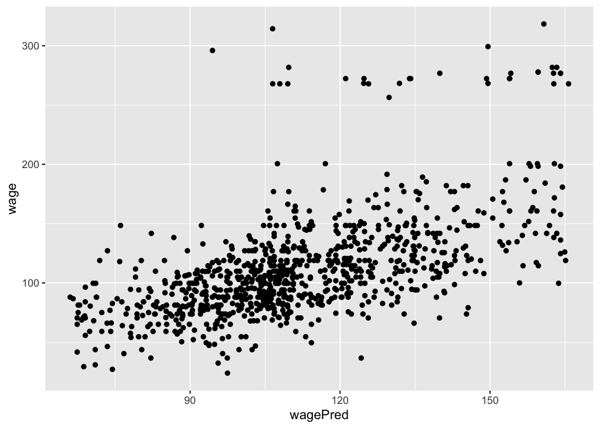

```r
testing$wagePred <- predict(modFit, testing)
g <- ggplot(data = testing,aes(x = wagePred,
                               y = wage))
g <- g + geom_point()
g
```

## Basic idea

1. Assume the data follow a probabilistic model.
2. Use Bayes’ theorem to identify optimal classifiers.

**Pros**

- Can take advantage of structure of the data.
- May be computationally convenient.
- Are reasonably accurate on real problems.

**Cons**

- Make additional assumptions about the data.
- When the model is incorrect, you may get reduced accuracy.

## Model based approach

1. The goal is to build parameteric model for conditional distribution
   $$\begin{align}
   \text{Pr} \left( Y = k \mid X = x \right)
   .
   \end{align}$$
2. A typical approach is to apply Bayes theorem:

$$\begin{align}
\text{Pr} \left( Y = k \mid X = x \right)
=
\frac
{\text{Pr} \left( X = x \mid Y = k \right)
\text{Pr} \left(Y = k \right)}
{\sum_{i}^{K}
\text{Pr}\left(X = x \mid Y = i \right)
\text{Pr} \left(Y = i \right)}
=
\frac
{f_k(x) \pi_k}
{\sum_{i}^{K} f_i(x) \pi_i}
.
\end{align}$$

3. Typically prior probabilities $\pi_i$, $i = 1, \ldots, K$ are set in advance.
4. One choice for the likelihoods is the Gaussian distribution
   $$\begin{align}
   f_i(x)
   =
   \text{Normal}\left( x \mid \mu_i, \sigma_i^2 \right)
   =
   \frac{1}{\sigma_i \sqrt{2\pi}}
   \exp{
   \left(
   -\frac{\left(x - \mu_i\right)^2}{\sigma_i^2}
   \right)
   }
   .
   \end{align}$$
5. Estimate the parameters $\left(\mu_i, \sigma^2_i \right)$ $i = 1, \ldots, K$.
6. Classify to the class with the highest value of
   $$\begin{align}
   \text{Pr} \left( Y = k \mid X = x \right)
   .
   \end{align}$$

## Classigying using the model

A range of models use this approach

- Linear discriminant analysis (LDA) assumes $f_k(x)$ is multivarate Gaussian with *same* covariances.
- Quadratic discriminant analysis (QDA) assumes $f_k(x)$ is multivarate Gaussian with *different* covariances.
- Model based prediction assumes more complicated versions for the covariance matrix.
- Naive Bayes assumes independence between features for model building.

## Why linear discriminant analysis?

Considering the log ratio of the probabilities of two classes, $k$ and $j$ then

$$\begin{align}
\log
\left(
\frac
{\text{Pr} \left( Y = k \mid X = x \right)}
{\text{Pr} \left( Y = j \mid X = x \right)}
\right)
=
\log
\frac
{f_k(x) \pi_k}
{f_j(x) \pi_j}
=
\log
\frac
{\pi_k}
{\pi_j}
-
\frac{1}{2}
\left( \mu_k + \mu_j \right)^{T}
\Sigma^{-1}
\left( \mu_k + \mu_j \right)
+
x^T
\Sigma^{-1}
\left( \mu_k + \mu_j \right)
\end{align}$$

## Discriminant function

$$\begin{align}
\delta_k(x)
=
\log \pi_k
-
\frac{1}{2}
\mu_k^{T}
\Sigma^{-1}
\mu_k
+
x^T \Sigma^{-1} \mu_k
\end{align}$$

- Decide on class based on

$$\begin{align}
Y(x) = \arg\max_{k} \delta_k(x)
\end{align}$$

- One way to estimate parameters is via maximum likelihood (ML).

## Naive Bayes

Suppose we have many predictors, we would want to model $\text{Pr} \left(Y = k \mid X_1, \ldots, X_m \right)$

$$\begin{align}
\text{Pr}
\left(Y = k \mid X_1, \ldots, X_m \right)
=
\frac
{\pi_k \text{Pr}
\left(X_1, \ldots, X_m \mid Y = k \right)}
{\sum_{i=1}^{K}
\pi_i \text{Pr}
\left(X_1, \ldots, X_m \mid Y = i \right)}
\end{align}$$

The likelihood is
$$\begin{align}
\text{Pr} \left(X_1, \ldots, X_m \mid Y = k \right)
=
\pi_k
\text{Pr} \left(X_1 \mid Y = k \right)
\text{Pr} \left(X_2 \mid X_1, Y = k \right)
\ldots
\text{Pr} \left(X_m \mid X_1, \ldots, X_{m-1}, Y = k \right)
\end{align}$$

Naive Bayes makes (naive) the assumption that the predictor variables are mutually independent, in which case
$$\begin{align}
\text{Pr}
\left(X_i \mid X_1, \ldots, X_{i-1}, Y = k \right)
=
\left(X_i \mid Y = k \right)
,
\quad
i = 2, \ldots, m.
\end{align}$$

so the likelihood then writes
$$\begin{align}
\text{Pr} \left(X_1, \ldots, X_m \mid Y = k \right)
=
\pi_k
\text{Pr} \left(X_1 \mid Y = k \right)
\text{Pr} \left(X_2 \mid Y = k \right)
\ldots
\text{Pr} \left(X_m \mid Y = k \right)
\end{align}$$

## Example Iris Data

```r
data(iris)
library(ggplot2)
names(iris)
```

```
## [1] "Sepal.Length" "Sepal.Width"  "Petal.Length" "Petal.Width"  "Species"
```

```r
table(iris$Species)
```

```
##
##     setosa versicolor  virginica
##         50         50         50
```

```r
inTrain <- createDataPartition(y = iris$Species,
                               p = 0.7,
                               list = FALSE)
training <- iris[inTrain,]
testing <- iris[-inTrain,]
dim(training)
```

```
## [1] 105   5
```

```r
dim(testing)
```

```
## [1] 45  5
```

```r
modLDA <- train(Species ~ .,
                data = training,
                method = 'lda')
predLDA <- predict(modLDA, testing)
table(testing$Species, predLDA)
```

```
##             predLDA
##              setosa versicolor virginica
##   setosa         15          0         0
##   versicolor      0         14         1
##   virginica       0          0        15
```

```r
library(klaR)
modNB <- train(Species ~ .,
                data = training,
                method = 'nb')
predNB <- predict(modNB, testing)
table(testing$Species, predNB)
```

```
##             predNB
##              setosa versicolor virginica
##   setosa         15          0         0
##   versicolor      0         13         2
##   virginica       0          1        14
```

```r
table(predLDA, predNB)
```

```
##             predNB
## predLDA      setosa versicolor virginica
##   setosa         15          0         0
##   versicolor      0         13         1
##   virginica       0          1        15
```